# Project 1

### Q3

Let’s look at the mean and standard deviation of ratings of bars using Ecuadorian beans.

```r
chocolate %>%
  filter(country_of_bean_origin == "Ecuador") %>%
  summarize(
      mean = mean(rating),
      sd = sd(rating),
      total = n()
            )
```

```
## # A tibble: 1 × 3
##    mean    sd total
##   <dbl> <dbl> <int>
## 1  3.16 0.512   219
```

For the **219 ratings** of Ecuadorian beans, the **average rating was 3.16** with a **standard deviation of 0.51**.

### Q4

Let’s look at average ratings by company of bars using Ecuadorian beans.

```r
chocolate %>%
  filter(country_of_bean_origin == "Ecuador") %>%
  group_by(company_manufacturer) %>%
  summarize(avg_rating = mean(rating)) %>%
  arrange(desc(avg_rating))
```

```
## # A tibble: 136 × 2
##    company_manufacturer   avg_rating
##    <chr>                       <dbl>
##  1 Amano                        4
##  2 Benoit Nihant                4
##  3 Beschle (Felchlin)           4
##  4 Durci                        4
##  5 Smooth Chocolator, The       4
##  6 Domori                       3.88
##  7 A. Morin                     3.75
##  8 Cacao Sampaka                3.75
##  9 Foundry                      3.75
## 10 Goodnow Farms                3.75
## # ℹ 126 more rows
```

Amano, Benoit Nihant, Beschle, Durci, and The Smooth Chocolator make the best chocolate from Ecuadorian beans, with an average rating of 4.

### Q5

Let’s look at which countries make the best chocolate on average.

```r
chocolate %>%
  group_by(country_of_bean_origin) %>%
  summarize(avg_rating = mean(rating)) %>%
  arrange(desc(avg_rating)) %>%
  head(3)
```

```
## # A tibble: 3 × 2
##   country_of_bean_origin avg_rating
##   <chr>                       <dbl>
## 1 Tobago                       3.62
## 2 China                        3.5
## 3 Sao Tome & Principe          3.5
```

The top 3 countries with the highest average ratings are **Tobago, China, and Sao Tome & Principe**.

### Q6

Some countries may produce beans used in very few bars, adding variability to the mean. Let’s only look at countries whose beans are used by 10 or more bars.

```r
chocolate %>%
  group_by(country_of_bean_origin) %>%
  summarize(
    avg_rating = mean(rating),
    count = n()
    )%>%
  arrange(desc(avg_rating)) %>%
  filter(count >= 10) %>%
  head(3)
```

```
## # A tibble: 3 × 3
##   country_of_bean_origin avg_rating count
##   <chr>                       <dbl> <int>
## 1 Solomon Islands              3.45    10
## 2 Congo                        3.32    11
## 3 Cuba                         3.29    12
```

Removing countries of bean origin with less than 10 chocolate bar reviews, the new top 3 countries are **Solomon Islands, Congo, and Cuba**.

### Q7

Looking at the `cocoa_percent` variable, let’s categorize it and calculate rating by cocoa percent category across countries.

```r
# step 1
# extract vector of countries of bean origin with <50 reviews
under50_reviews <- chocolate %>%
  group_by(country_of_bean_origin) %>%
  summarise(count = n()) %>%
  filter(count < 50) %>%
  select(country_of_bean_origin) %>%
  pull()

# alternatively, without identifying the list of countries w/ <50 reviews,
choc_groups <- chocolate %>%
  group_by(country_of_bean_origin) %>%
  filter(n() >= 50) %>%
  ungroup()
```

```r
# step 2
# create perc_group to group chocolate percentages
choc_groups <- chocolate %>%
  filter(!country_of_bean_origin %in% under50_reviews) %>%
  mutate(
    perc_group = substr(cocoa_percent, 1, 2),
    perc_group = factor(case_when(
      perc_group < 60 ~ "<60%",
      perc_group >= 60 & perc_group < 70 ~ ">=60 to <70%",
      perc_group >= 70 & perc_group < 90 ~ ">=70 to <90%",
      perc_group >= 90 ~ ">=90%"
    )))
```

```r
# step 3
# relevel perc_group in "numerical" order
choc_groups <- choc_groups %>%
  mutate(perc_group = forcats::fct_relevel(choc_groups$perc_group, c("<60%", ">=60 to <70%", ">=70 to <90%", ">=90%")))
```

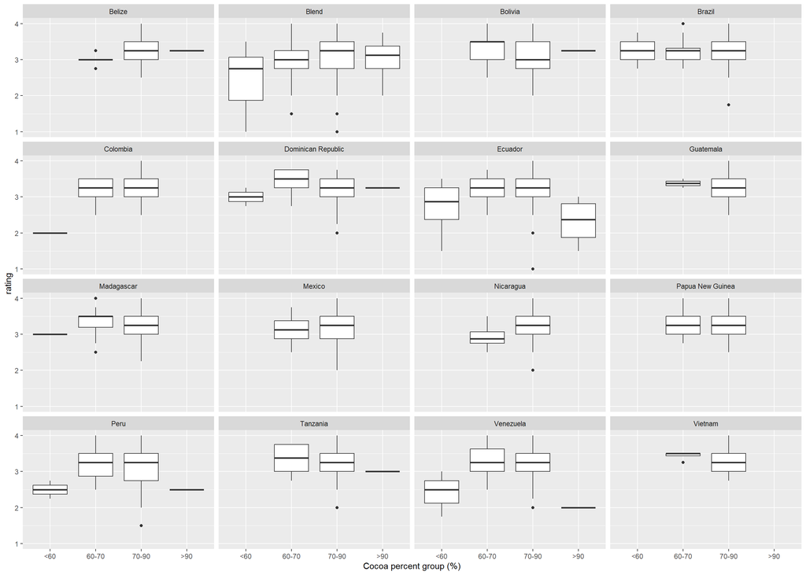

```r
# step 4
# boxplot of rating by country/percentage group
choc_groups %>%
  ggplot(mapping = aes(x = perc_group, y = rating)) +
  geom_boxplot() +
  facet_wrap(~country_of_bean_origin, ncol = 4) +
  labs(x = "Cocoa percent group (%)") +
  scale_x_discrete(labels = c("<60", "60-70", "70-90", ">90"))
```

The highest-rated category is generally the >=70% to <90% category, though the >=60% to <70% category is similarly rated. The pattern of increased rating as chocolate percentage increases (up to the third category) generally holds, but there are a few exceptions (e.g. Madagascar, the Dominican Republic)

## Part 2

```r
# load gapminder data
library(gapminder)
str(gapminder)
```

```
## tibble [1,704 × 6] (S3: tbl_df/tbl/data.frame)
##  $ country  : Factor w/ 142 levels "Afghanistan",..: 1 1 1 1 1 1 1 1 1 1 ...
##  $ continent: Factor w/ 5 levels "Africa","Americas",..: 3 3 3 3 3 3 3 3 3 3 ...
##  $ year     : int [1:1704] 1952 1957 1962 1967 1972 1977 1982 1987 1992 1997 ...
##  $ lifeExp  : num [1:1704] 28.8 30.3 32 34 36.1 ...
##  $ pop      : int [1:1704] 8425333 9240934 10267083 11537966 13079460 14880372 12881816 13867957 16317921 22227415 ...
##  $ gdpPercap: num [1:1704] 779 821 853 836 740 ...
```

Looking at the gapminder data, we’ll take the unique combinations of country and continent to add the continent name to the chocolate dataset.

```r
# task 1
# joining country/continent from gapminder into chocolate
choc_withcont <- gapminder %>%
  select(country, continent) %>%
  distinct(country, continent) %>%
  right_join(chocolate, by = c("country" = "country_of_bean_origin"))
```

```r
# Let's check for missing continents
choc_withcont %>%
  filter(is.na(continent)) %>%
  select(country, continent) %>%
  distinct(country, continent)
```

```
## # A tibble: 24 × 2
##    country          continent
##    <chr>            <fct>
##  1 Fiji             <NA>
##  2 Burma            <NA>
##  3 Papua New Guinea <NA>
##  4 Sao Tome         <NA>
##  5 Vanuatu          <NA>
##  6 Trinidad         <NA>
##  7 Belize           <NA>
##  8 Blend            <NA>
##  9 Grenada          <NA>
## 10 Congo            <NA>
## # ℹ 14 more rows
```

```r
# filling in missing continents by hand
choc_withcont <- choc_withcont %>%
  mutate(
    # combining different regions/names for a single country
    country = case_when(
      country %in% c("Sumatra", "Sulawesi") ~ "Indonesia",
      country %in% c("Sao Tome", "Sao Tome & Principe", "Principe") ~ "Sao Tome & Principe",
      country %in% c("Trinidad", "Tobago") ~ "Trinidad & Tobago",
      .default = country
    ),
    continent = case_when(
      country %in% c("Fiji", "Papua New Guinea", "Vanuatu", "Solomon Islands", "Samoa") ~ "Oceania",
      country %in% c("Burma", "Indonesia") ~ "Asia",
      country %in% c("Sao Tome & Principe", "Congo", "Ivory Coast", "DR Congo") ~ "Africa",
      country %in% c("Trinidad & Tobago", "Belize", "Grenada", "Martinique", "St. Lucia", "U.S.A.", "St.Vincent-Grenadines", "Suriname") ~ "Americas",
      .default = continent
    )
  )

# check to see if we are still missing anything
choc_withcont %>%
  filter(is.na(continent)) %>%
  select(country, continent) %>%
  distinct(country, continent)
```

```
## # A tibble: 1 × 2
##   country continent
##   <chr>   <chr>
## 1 Blend   <NA>
```

Great! Now we can proceed to filter out countries with fewer than 10 ratings and bars that are not single-origin (Blend).

```r
# tasks 2 & 3
choc_withcont <- choc_withcont %>%
  group_by(country) %>%
  filter(
    n() >= 10,
    country != "Blend") %>%
  ungroup()
```

Here are the violin plots of rating by continent:

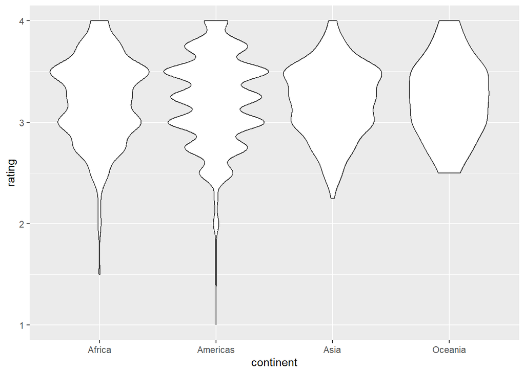

```r
# violin plot of rating by continent
choc_withcont %>%
  ggplot(mapping = aes(x = continent, y = rating)) +
    geom_violin()
```

Ratings are similar across continents, but the distributions vary a bit.

## Part 3

We also have ingredient and characteristic information about each bar! Let’s separate these columns into individual component ingredients and (a select few) characteristics, then find the % of bars from each year that have each ingredient/characteristic.

```r
# task 1
# add in a column for each ingredient
choc_ingr_char<- chocolate %>%
  replace_na(list(ingredients = "")) %>%
  mutate(
    beans = str_detect(ingredients, "B") * 1,
    sugar = str_detect(ingredients, "S[^a]+") * 1,
    cocoa_butter = str_detect(ingredients, "C") * 1,
    vanilla = str_detect(ingredients, "V") * 1,
    lethicin = str_detect(ingredients, "L") * 1,
    salt = str_detect(ingredients, "Sa") * 1
  )
```

```r
# task 2
# add in a column for each characteristic
choc_ingr_char <- choc_ingr_char %>%
  mutate(
    char_cocoa = str_detect(most_memorable_characteristics, "cocoa") * 1,
    char_sweet = str_detect(most_memorable_characteristics, "sweet") * 1,
    char_nutty = str_detect(most_memorable_characteristics, "nutty") * 1,
    char_creamy = str_detect(most_memorable_characteristics, "creamy") * 1,
    char_roasty = str_detect(most_memorable_characteristics, "roasty") * 1,
    char_earthy = str_detect(most_memorable_characteristics, "earthy") * 1
  )
```

```r
# task 3
# take mean across char/ingred per year, then convert to long dataset
choc_feature_means <- choc_ingr_char %>%
  group_by(review_date) %>%
  summarize(across(beans:char_earthy, mean)) %>%
  pivot_longer(-review_date, names_to = "feature", values_to = "mean_score")

choc_feature_means
```

```
## # A tibble: 192 × 3
##    review_date feature      mean_score
##          <dbl> <chr>             <dbl>
##  1        2006 beans            0.968
##  2        2006 sugar            0.919
##  3        2006 cocoa_butter     0.903
##  4        2006 vanilla          0.694
##  5        2006 lethicin         0.694
##  6        2006 salt             0
##  7        2006 char_cocoa       0.210
##  8        2006 char_sweet       0.161
##  9        2006 char_nutty       0.0323
## 10        2006 char_creamy      0.242
## # ℹ 182 more rows
```

## Part 4

Using our calculated information about yearly usage of each ingredient and characteristic, let’s make a scatter plot!

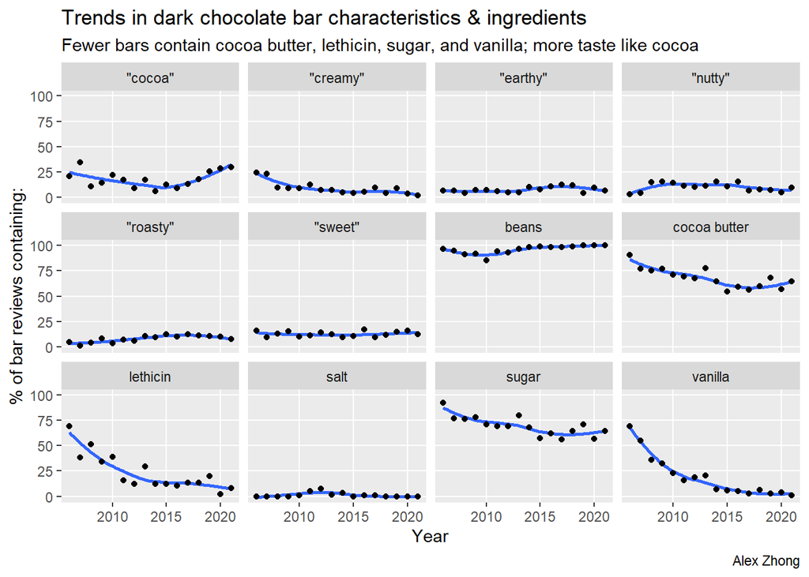

```r
# plot of ingredient/characteristic % usage by year
choc_feature_means %>%
  # Replacing char_ with double quotes around characteristic
  mutate(
    is_char = str_detect(feature, "char_"),
    feature = str_replace_all(feature, "^char_[a-z]+", dQuote),
    feature = str_replace_all(feature, c("char_" = "", "_" = " "))
    ) %>%
  ggplot(mapping = aes(x = review_date, y = mean_score*100)) +
  geom_smooth(method = "loess", se = FALSE) +
  geom_point() +
  facet_wrap(~feature, ncol = 4) +
  labs(
    title = "Trends in dark chocolate bar characteristics & ingredients",
    subtitle = "Fewer bars contain cocoa butter, lethicin, sugar, and vanilla; more taste like cocoa",
    x = "Year",
    y = "% of bar reviews containing:",
    caption = "Alex Zhong"
  ) +
  theme(
    panel.grid.minor = element_blank()
  )
```

## Part 5

Let’s use this same “mean score” by year of just characteristics to make a bad plot. I will note that I tried to make this in the style of an enthusiastic and well-meaning plotter, so most choices might genuinely be defensible.

[figure not shown]

```r
choc_jpg <- readJPEG(here("Homework", "exp_bars.jpg"))

choc_feature_means %>%
  filter(str_detect(choc_feature_means$feature, "char")) %>%
  ggplot(mapping = aes(x = review_date, y = mean_score, color = feature)) +
  geom_step() +
  annotation_raster(choc_jpg, 2016, 2021, 0.5, 1) +
  scale_color_brewer(palette = "Oranges") +
  scale_x_continuous(breaks = 2006:2021) +
  scale_y_continuous(breaks = seq(0, 1, 0.05), limits = c(0,1)) +
  labs(title = "My chocolate bar plot (yum!!!)") +
  theme(
    plot.background = element_rect(fill = "chocolate3"),
    panel.background = element_rect(fill = "chocolate1"),
    panel.grid = element_line(color = "chocolate4", linetype = "longdash", linewidth = 1),
    legend.background = element_rect(fill = "chocolate"),
    legend.position = c(0.5, 0.5),
    plot.title = element_text(color = "white"),
    axis.title = element_text(size = 5),
    axis.text.x = element_text(angle = 90),
    axis.text.y = element_text(angle = -45)
    )
```

Image from [Flavors of Cacao](http://flavorsofcacao.com/experiencing_chocolate.html).

My customizations are:

1. I **omitted the subtitle/caption** and used an **un-descriptive title**. Adding descriptive text would help to summarize findings and provide more context to the figure.
2. I used **the wrong geom/type of chart**. Using a more appropriate geom would convey plot information better.
3. I **didn’t use descriptive axis labels**. Changing axis labels from variable names would enhance figure readability.
4. I used **muted colors for data** and **similar/distracting colors for the plot background**. Using colors that make data trends stand out more would enhance figure readability.
5. I used **crowded axis labels**. Reducing axis labels when appropriate would help to reduce overcrowding.
6. I had a **crowded plot** with many lines. Simplifying the plot (fewer lines) would enhance the message of each plot within the figure.
7. I used **dark gridlines**. Using light or no gridlines would help to draw focus to data.
8. I used **un-intuitively angled axis labels** Using horizontal/vertical or appropriately angled text would enhance figure readability.
9. I used an **inappropriately-sized and placed legend**. Placing the legend in an appropriate location at a readable yet small size will draw more attention to the trends presented in the plot.

## Part 6

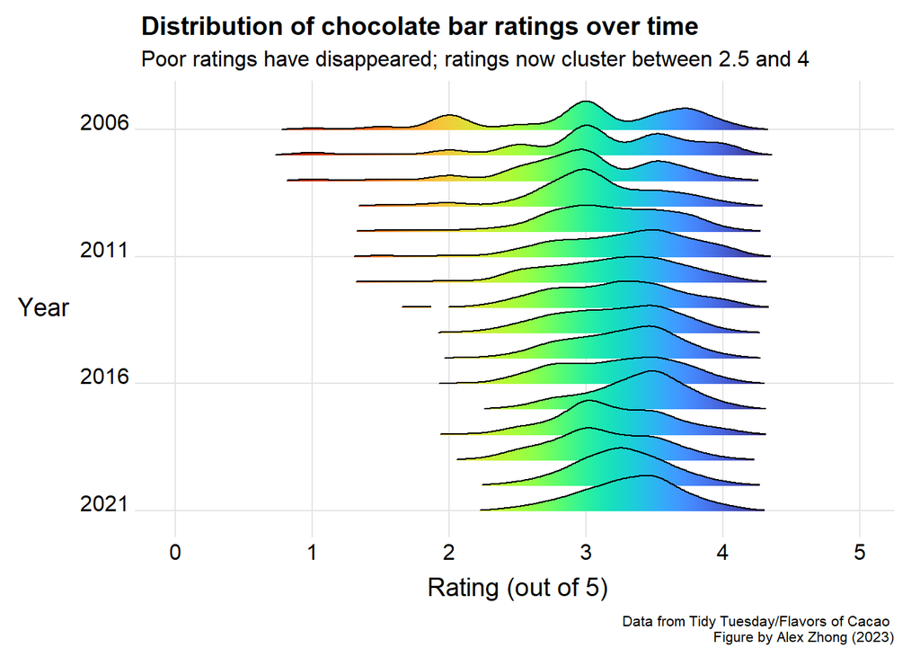

```r
ggplot(chocolate, mapping = aes(x = rating, y = review_date, group = review_date, fill = after_stat(x))) +
  geom_density_ridges_gradient(scale = 1.5, rel_min_height = 0.01, show.legend = FALSE) +
  scale_fill_viridis(option = "H", direction = -1) +
  theme_ridges(center_axis_labels = TRUE) +
  labs(
    title = "Distribution of chocolate bar ratings over time",
    subtitle = "Poor ratings have disappeared; ratings now cluster between 2.5 and 4",
    caption = "Data from Tidy Tuesday/Flavors of Cacao \n Figure by Alex Zhong (2023)",
    x = "Rating (out of 5)",
    y = "Year"
    ) +
  scale_x_continuous(limits = c(0,5)) +
  scale_y_reverse(breaks = seq(2006, 2021, 5)) +
  theme(
    axis.title.y = element_text(angle = 0),
    plot.caption = element_text(size = 8)
        )
```

```r
options(width = 120)
```